## Data Wrangling Part 1

[figure not shown]

[figure not shown]

[figure not shown]

The video below gives a brief overview of the content covered in this section of the tutorial. All the [Data Wrangling slides](http://htmlpreview.github.io/?https://github.com/CWWhitney/teaching_R/blob/master/Data_Wrangling_Rpres/Data_Wrangling.html#/) are also available as a web page.

[video not shown]

### Notes on R

- Tidy code style using tidyR
- Clean and intuitive functions using dplyr
- Concise code using magrittr ‘Ceci n’est pas une pipe’

[figure not shown]

### Notes on R: About process

- “[…] writing R code is a hedonistically artistic, left-brained, paint-in-your-hair sort of experience […]
- learn how to code the same way we learned how to catch salamanders as children – trial and error, flipping over rocks till we get a reward […]
- once the ecstasy of creation has swept over us, we awake late the next morning to find our canvas covered with 2100 lines of R code […]
- Heads throbbing with a statistical absinthe hangover, we trudge through it slowly over days, trying to figure out what we did.”

  *Andrew MacDonald*

### Notes on R: Focus

[figure not shown]

### Notes on R: Keeping track of work

[figure not shown]

Keep it tidy

When writing .R files use the `#` symbol to annotate and not run lines. This is a great way to make notes for others and for future you.

We will talk later about using other file types like `Rmarkdown` for organizing R script and other associated languages. There it will be possible to add a lot more information and text, citations etc. An .R file is intended for code but we can still keep it organized in sections by ending headers with `----` or `####` annotation.

`# Section 1 ----`

`# Section 2 ####`

`# Section 3 ####`

Look for the `Table of contents` in the upper right console of the RStudio scripting pane (next to the `Run` button).

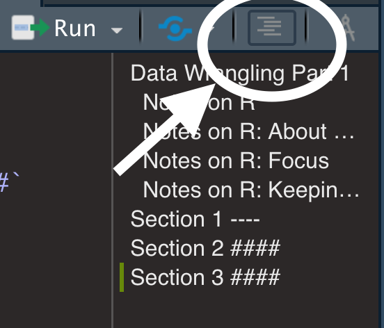

Read more tips in the [Tidyverse Style guide](http://style.tidyverse.org/).